# 07-project2

Author

Milo Coolman

All work presented is my own, and I have followed all rules for collaboration. I have not discussed this project with anyone outside of students currently enrolled in this course, and I have listed any such students at the top of my project. If I used and AI on this assignment, I have clearly stated both (1) what my search prompt was and (2) what I used from the AI answer. - Milo Coolman

# Question 1

```r
evals_df
```

```
# A tibble: 234 × 10
   Term  Course Question         `Agree strongly` Agree `Agree Somewhat` Neutral
   <chr> <chr>  <chr>                       <dbl> <dbl>            <dbl>   <dbl>
 1 F19   113-02 1. Course has b…                9     9                1       5
 2 F19   113-02 2. Effectively …               12     8                1       2
 3 F19   113-02 3. Environment …               11     8                2       3
 4 F19   113-02 5a. Fair Assess…                5    13                3       1
 5 F19   113-02 5b. Timely Asse…                8    12                1       2
 6 F19   113-02 5c. Constructiv…                5     8                4       6
 7 F19   113-02 6a. Recommend I…               11     6                4       2
 8 F19   113-02 6b. Recommend C…               11     7                3       1
 9 F19   113-02 6c. Instructor …               11     6                4       2
10 F19   213-02 1. Course has b…                7    13                1       0
# ℹ 224 more rows
# ℹ 3 more variables: `Disagree Somewhat` <dbl>, Disagree <dbl>,
#   `Disagree Strongly` <dbl>
```

```r
evals_df_q1 <- evals_df |>
  mutate(Question_Short = case_when(
  Question == "1. Course has been a valuable educational experience" ~ "1. Valuable",
  Question == "2. Effectively Organized" ~ "2. Organized",
  Question == "3. Environment Conducive to Learning" ~ "3. Conducive",
  Question == "5a. Fair Assessment of Student work" ~ "5a. Fair",
  Question == "5b. Timely Assessment of Student Work" ~ "5b. Timely",
  Question == "5c. Constructive Assessment of Student Work" ~ "5c. Constructive",
  Question == "6a. Recommend Instructor to another student" ~ "6a. Recommend_Instructor",
  Question == "6b. Recommend Course to another student" ~ "6b. Recommend_Course",
  Question == "6c. Instructor was an effective teacher" ~ "6c. Effective")) |>
  relocate(Question, .after = "Disagree Strongly") |>
  relocate(Question_Short, .before = "Agree strongly") |>
  rename(agree_strongly = "Agree strongly",
         agree = "Agree",
         agree_somewhat = "Agree Somewhat",
         neutral = "Neutral",
         disagree_somewhat = "Disagree Somewhat",
         disagree = "Disagree",
         disagree_strongly = "Disagree Strongly")
evals_df_q1
```

```
# A tibble: 234 × 11
   Term  Course Question_Short       agree_strongly agree agree_somewhat neutral
   <chr> <chr>  <chr>                         <dbl> <dbl>          <dbl>   <dbl>
 1 F19   113-02 1. Valuable                       9     9              1       5
 2 F19   113-02 2. Organized                     12     8              1       2
 3 F19   113-02 3. Conducive                     11     8              2       3
 4 F19   113-02 5a. Fair                          5    13              3       1
 5 F19   113-02 5b. Timely                        8    12              1       2
 6 F19   113-02 5c. Constructive                  5     8              4       6
 7 F19   113-02 6a. Recommend_Instr…             11     6              4       2
 8 F19   113-02 6b. Recommend_Course             11     7              3       1
 9 F19   113-02 6c. Effective                    11     6              4       2
10 F19   213-02 1. Valuable                       7    13              1       0
# ℹ 224 more rows
# ℹ 4 more variables: disagree_somewhat <dbl>, disagree <dbl>,
#   disagree_strongly <dbl>, Question <chr>
```

# Question 2

```r
evals_df_q2 <- evals_df_q1 |>
  group_by(Term, Course, Question_Short) |>
  summarise(n_total = sum(agree_strongly,
                           agree, agree_somewhat,
                           neutral, disagree_somewhat,
                           disagree, disagree_strongly),
            prop_agree = sum(agree_strongly, agree) / n_total)
evals_df_q2
```

```
# A tibble: 234 × 5
# Groups:   Term, Course [26]
   Term  Course Question_Short           n_total prop_agree
   <chr> <chr>  <chr>                      <dbl>      <dbl>
 1 F19   113-02 1. Valuable                   24      0.75
 2 F19   113-02 2. Organized                  24      0.833
 3 F19   113-02 3. Conducive                  24      0.792
 4 F19   113-02 5a. Fair                      24      0.75
 5 F19   113-02 5b. Timely                    24      0.833
 6 F19   113-02 5c. Constructive              24      0.542
 7 F19   113-02 6a. Recommend_Instructor      24      0.708
 8 F19   113-02 6b. Recommend_Course          24      0.75
 9 F19   113-02 6c. Effective                 23      0.739
10 F19   113-04 1. Valuable                   27      0.630
# ℹ 224 more rows
```

# Question 3

```r
evals_df_q3 <- evals_df_q1 |> separate(col = Course, into = c("Course", "Section"), sep = "-") |>
  mutate(Course = case_when(Course == "4005" ~ "334",
                            Course == "113" ~ "113",
                            Course == "213" ~ "213",
                            Course == "334" ~ "334",
                            Course == "234" ~ "234")) |>
  group_by(Course, Question_Short) |>
  summarise(n_total = sum(agree_strongly, agree, agree_somewhat, neutral,
                          disagree_somewhat, disagree, disagree_strongly),
            prop_agree = sum(agree_strongly, agree) / n_total)
evals_df_q3
```

```
# A tibble: 36 × 4
# Groups:   Course [4]
   Course Question_Short           n_total prop_agree
   <chr>  <chr>                      <dbl>      <dbl>
 1 113    1. Valuable                  329      0.809
 2 113    2. Organized                 327      0.911
 3 113    3. Conducive                 327      0.826
 4 113    5a. Fair                     329      0.787
 5 113    5b. Timely                   329      0.863
 6 113    5c. Constructive             328      0.723
 7 113    6a. Recommend_Instructor     328      0.845
 8 113    6b. Recommend_Course         327      0.771
 9 113    6c. Effective                326      0.859
10 213    1. Valuable                   58      0.948
# ℹ 26 more rows
```

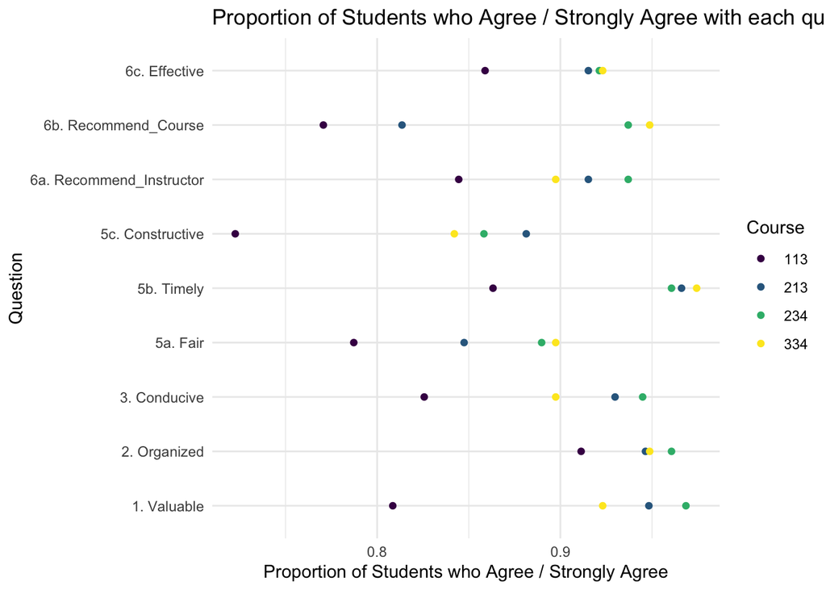

```r
ggplot(data = evals_df_q3, aes(x = prop_agree, y = Question_Short)) +
  geom_point(aes(colour = Course, group = Course)) +
  scale_colour_viridis_d() +
  theme_minimal() +
  labs(title = "Proportion of Students who Agree / Strongly Agree with each question by Course",
       x = "Proportion of Students who Agree / Strongly Agree",
       y = "Question")
```

# Question 4

```r
evals_df_q3 |> summarise(avg_responses = mean(n_total))
```

```
# A tibble: 4 × 2
  Course avg_responses
  <chr>          <dbl>
1 113            328.
2 213             58.3
3 234            127
4 334             38.9
```

# Question 5

Overall, 113 has the lowest proportion of students agreeing or strongly agreeing for every single question. After that, the other 3 classes on average have relatively similar proportions of students agreeing for most questions. 213 is next up as generally the worst, with a big discrepancy compared to 234 and 334 when it comes to students wanting to recommend the course to other students, but aside from that, 213, 234, and 334 are fairly close together for every other question.

# Time Analysis

For this question we are looking at data from the student evaluations of Prof. Professorson’s 4 classes. Students answered 9 questions, on a scale from Agree Strongly, Agree, Agree Somewhat, Neutral, Disagree Somewhat, Disagree, and Disagree Strongly. We want to determine whether or not Prof. Professorson has been improving his teaching as time goes on, and to do so we are looking at the proportion of students who either Agree or Agree Strongly with the 9 questions.

```r
evals_df_timeanalysis <- evals_df_q1 |> separate(Course, c("Course", "Section"), "-") |>
  mutate(Course = case_when(Course == "4005" ~ "334",
                            Course == "113" ~ "113",
                            Course == "213" ~ "213",
                            Course == "334" ~ "334",
                            Course == "234" ~ "234")) |>
  group_by(Term, Course, Question_Short) |>
  summarise(n_total = sum(agree_strongly, agree, agree_somewhat, neutral,
                          disagree_somewhat, disagree, disagree_strongly),
            prop_agree = sum(agree_strongly, agree) / n_total)
evals_df_timeanalysis
```

```
# A tibble: 162 × 5
# Groups:   Term, Course [18]
   Term  Course Question_Short           n_total prop_agree
   <chr> <chr>  <chr>                      <dbl>      <dbl>
 1 F19   113    1. Valuable                   51      0.686
 2 F19   113    2. Organized                  49      0.837
 3 F19   113    3. Conducive                  50      0.66
 4 F19   113    5a. Fair                      50      0.62
 5 F19   113    5b. Timely                    51      0.824
 6 F19   113    5c. Constructive              50      0.52
 7 F19   113    6a. Recommend_Instructor      50      0.64
 8 F19   113    6b. Recommend_Course          51      0.647
 9 F19   113    6c. Effective                 50      0.72
10 F19   213    1. Valuable                   21      0.952
# ℹ 152 more rows
```

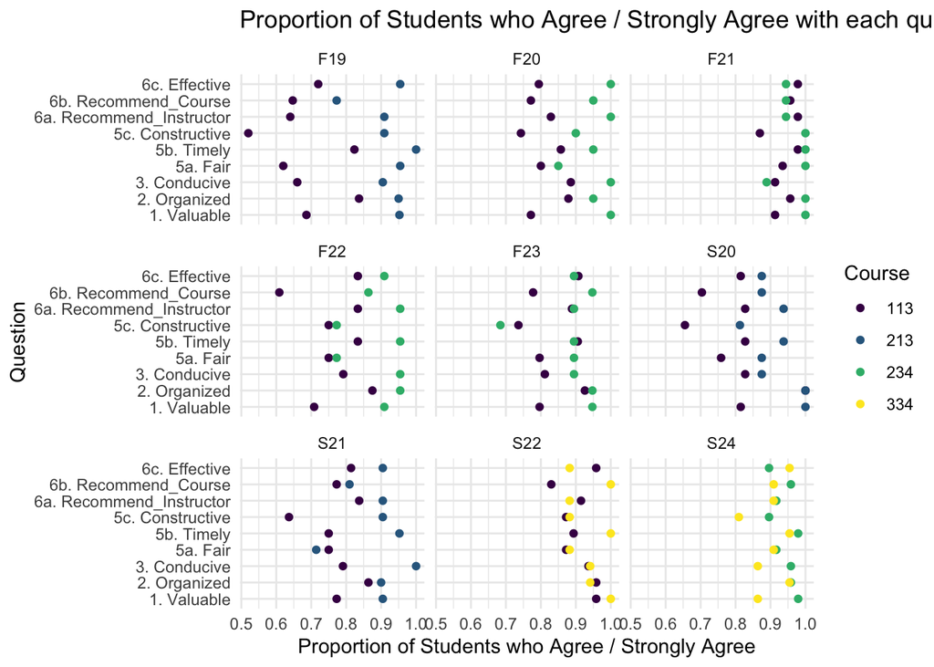

```r
ggplot(data = evals_df_timeanalysis, aes(x = prop_agree, y = Question_Short)) +
  geom_point(aes(colour = Course)) +
  facet_wrap(~ Term) +
  scale_colour_viridis_d() +
  theme_minimal() +
  labs(title = "Proportion of Students who Agree / Strongly Agree with each question by Course & Term",
       x = "Proportion of Students who Agree / Strongly Agree",
       y = "Question")
```

```r
evals_df_113 <- evals_df_timeanalysis |> ungroup() |> filter(Course == "113") |>
  arrange(Question_Short)
evals_df_213 <- evals_df_timeanalysis |> ungroup() |> filter(Course == "213") |>
  arrange(Question_Short)
evals_df_234 <- evals_df_timeanalysis |> ungroup() |> filter(Course == "234") |>
  arrange(Question_Short)
evals_df_334 <- evals_df_timeanalysis |> ungroup() |> filter(Course == "334") |>
  arrange(Question_Short)
```

```r
evals_df_113
```

```
# A tibble: 72 × 5
   Term  Course Question_Short n_total prop_agree
   <chr> <chr>  <chr>            <dbl>      <dbl>
 1 F19   113    1. Valuable         51      0.686
 2 F20   113    1. Valuable         35      0.771
 3 F21   113    1. Valuable         46      0.913
 4 F22   113    1. Valuable         24      0.708
 5 F23   113    1. Valuable         54      0.796
 6 S20   113    1. Valuable         27      0.815
 7 S21   113    1. Valuable         44      0.773
 8 S22   113    1. Valuable         48      0.958
 9 F19   113    2. Organized        49      0.837
10 F20   113    2. Organized        33      0.879
# ℹ 62 more rows
```

```r
evals_df_213
```

```
# A tibble: 27 × 5
   Term  Course Question_Short n_total prop_agree
   <chr> <chr>  <chr>            <dbl>      <dbl>
 1 F19   213    1. Valuable         21      0.952
 2 S20   213    1. Valuable         16      1
 3 S21   213    1. Valuable         21      0.905
 4 F19   213    2. Organized        20      0.95
 5 S20   213    2. Organized        16      1
 6 S21   213    2. Organized        20      0.9
 7 F19   213    3. Conducive        21      0.905
 8 S20   213    3. Conducive        16      0.875
 9 S21   213    3. Conducive        20      1
10 F19   213    5a. Fair            22      0.955
# ℹ 17 more rows
```

```r
evals_df_234
```

```
# A tibble: 45 × 5
   Term  Course Question_Short n_total prop_agree
   <chr> <chr>  <chr>            <dbl>      <dbl>
 1 F20   234    1. Valuable         20      1
 2 F21   234    1. Valuable         18      1
 3 F22   234    1. Valuable         22      0.909
 4 F23   234    1. Valuable         19      0.947
 5 S24   234    1. Valuable         48      0.979
 6 F20   234    2. Organized        20      0.95
 7 F21   234    2. Organized        18      1
 8 F22   234    2. Organized        22      0.955
 9 F23   234    2. Organized        19      0.947
10 S24   234    2. Organized        48      0.958
# ℹ 35 more rows
```

```r
evals_df_334
```

```
# A tibble: 18 × 5
   Term  Course Question_Short           n_total prop_agree
   <chr> <chr>  <chr>                      <dbl>      <dbl>
 1 S22   334    1. Valuable                   17      1
 2 S24   334    1. Valuable                   22      0.864
 3 S22   334    2. Organized                  17      0.941
 4 S24   334    2. Organized                  22      0.955
 5 S22   334    3. Conducive                  17      0.941
 6 S24   334    3. Conducive                  22      0.864
 7 S22   334    5a. Fair                      17      0.882
 8 S24   334    5a. Fair                      22      0.909
 9 S22   334    5b. Timely                    17      1
10 S24   334    5b. Timely                    22      0.955
11 S22   334    5c. Constructive              17      0.882
12 S24   334    5c. Constructive              21      0.810
13 S22   334    6a. Recommend_Instructor      17      0.882
14 S24   334    6a. Recommend_Instructor      22      0.909
15 S22   334    6b. Recommend_Course          17      1
16 S24   334    6b. Recommend_Course          22      0.909
17 S22   334    6c. Effective                 17      0.882
18 S24   334    6c. Effective                 22      0.955
```

For class 113, student’s agreeing or strongly agreeing has been on a general trend upwards from the first semester teaching all the way to the most recent semester. It has not increased every single semester, but the general trend is one that is improving. That said, giving constructive feedback seems to be the biggest weakness, as there has not been a single semester in which 90% or more students agreed with this. For class 213, it is hard to see trends as there are only 3 semesters of data, but one big thing is that students have been increasingly thinking that the grading is unfair. Many students would not want to recommend this course, and as with 113, giving constructive feedback is one of the weakest areas. Class 234 is strange. We still see that constructive feedback is the worst category, however it seems almost as if for many questions there has been a slight backslide in the reviews from students. As with class 213, class 334 has only been taught for 2 semesters, but we continue to see that giving constructive feedback is by far the category that needs more work.